# Challenger dataset

Kevin Greenberg

11/7/2020

# Overview of the dataset

The dataset looks at the challenger test flights, specifically the o-rings that were under stress based on the temperature and pressure. The purpose of here is to provide a simple report for presenting basic visualizations, statitics, and prediction for the dataset. #

### Summary statistics for the data

|  | o_ring_ct | distress_ct | temperature | pressure | launch_id |
| --- | --- | --- | --- | --- | --- |
|  | Min. :6 | Min. :0.0000 | Min. :53.00 | Min. : 50.0 | Min. : 1.0 |
|  | 1st Qu.:6 | 1st Qu.:0.0000 | 1st Qu.:67.00 | 1st Qu.: 75.0 | 1st Qu.: 6.5 |
|  | Median :6 | Median :0.0000 | Median :70.00 | Median :200.0 | Median :12.0 |
|  | Mean :6 | Mean :0.3043 | Mean :69.57 | Mean :152.2 | Mean :12.0 |
|  | 3rd Qu.:6 | 3rd Qu.:0.5000 | 3rd Qu.:75.00 | 3rd Qu.:200.0 | 3rd Qu.:17.5 |
|  | Max. :6 | Max. :2.0000 | Max. :81.00 | Max. :200.0 | Max. :23.0 |

### Visualize the data

We see that as the temperature decreases and the pressure increases, the likelihood of o-ring distress increases. #

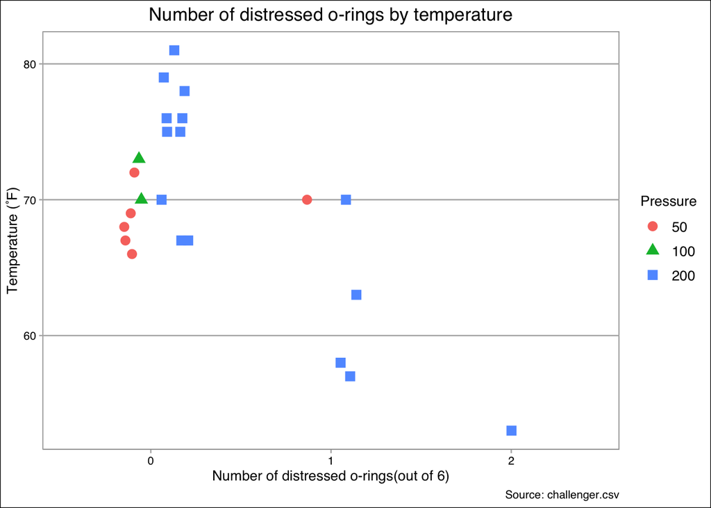

### Linear regression modeling the data

|  | distress_ct |  |  | distress_ct |  |  | distress_ct |  |  |
| --- | --- | --- | --- | --- | --- | --- | --- | --- | --- |
| Predictors | Estimates | CI | p | Estimates | CI | p | Estimates | CI | p |
| (Intercept) | 4.30 | 2.57 – 6.03 | **<0.001** | 4.05 | 2.36 – 5.73 | **<0.001** | -3.48 | -16.24 – 9.27 | 0.574 |
| temperature | -0.06 | -0.08 – -0.03 | **<0.001** | -0.06 | -0.08 – -0.03 | **<0.001** | 0.05 | -0.13 – 0.24 | 0.571 |
| pressure |  |  |  | 0.00 | -0.00 – 0.00 | 0.097 | 0.04 | -0.02 – 0.11 | 0.205 |
| temperature * pressure |  |  |  |  |  |  | -0.00 | -0.00 – 0.00 | 0.228 |
| Observations | 23 |  |  | 23 |  |  | 23 |  |  |
| R<sup>2</sup> / R<sup>2</sup> adjusted | 0.527 / 0.504 |  |  | 0.589 / 0.548 |  |  | 0.620 / 0.560 |  |  |

### Comparing the models

The different linear regression models do not significantly vary, indicating the simplest model is the most effective in terms accounting for variance and efficiency.

| Res.Df | RSS | Df | Sum of Sq | F | Pr(>F) |
| --- | --- | --- | --- | --- | --- |
| 21 | 3.252064 | NA | NA | NA | NA |
| 20 | 2.824713 | 1 | 0.4273508 | 3.109378 | 0.0939187 |
| 19 | 2.611348 | 1 | 0.2133650 | 1.552431 | 0.2279223 |

### Prediction on launch day:

The temperature during launch was 36˚F and based on our basic linear regression it is predicted 2.2330159 o-rings will be distressed. This indicates that even with a simple algorithm it can be predicted that launchng the challenger on a cold day was dangerous.

#### Given the dataset only has 23 observations, there is no need to run a more complex alogrithm that requires training, validation and test datasets.

Jump to top Return to [Kevin Greenberg's Portfolio](https://www.espn.com/)